# IODS course project

Antti Kääriälä

# About the project

*Write a short description about the course and add a link to your github repository here. This is an R markdown (.Rmd) file so you can use R markdown syntax. See the ‘Useful links’ page in the mooc area (chapter 1) for instructions.*

This is a neat data analysis course.

Here is a link to my course repo: https://github.com/akaariala/IODS-project

Hmmm… why don’t I see changes in my course diary?

Oh, now I do!

# Regression and model validation

*Describe the work you have done this week and summarize your learning.*

- Describe your work and results clearly.
- Assume the reader has an introductory course level understanding of writing and reading R code as well as statistical methods
- Assume the reader has no previous knowledge of your data or the more advanced methods you are using

### Data and its dimensions and structure (task 1)

The number of observations is 166, and there are 7 variables in the data. The variables include respondents gender and age. In addition, the data includes variables measuring respondents global attitude to statistics and sum of all exam points, as well as variables measuring to what extent the respondents approach learning by deep, startegic, and surface approaches.

The data has the following structure:

```
## Classes 'tbl_df', 'tbl' and 'data.frame':    166 obs. of  7 variables:
##  $ gender  : Factor w/ 2 levels "F","M": 1 2 1 2 2 1 2 1 2 1 ...
##  $ Age     : int  53 55 49 53 49 38 50 37 37 42 ...
##  $ Attitude: int  37 31 25 35 37 38 35 29 38 21 ...
##  $ deep    : num  3.58 2.92 3.5 3.5 3.67 ...
##  $ stra    : num  3.38 2.75 3.62 3.12 3.62 ...
##  $ surf    : num  2.58 3.17 2.25 2.25 2.83 ...
##  $ Points  : int  25 12 24 10 22 21 21 31 24 26 ...
```

### Graphical overview of the data and summaries of the variables (task 2)

Figure 1 shows the distributions of the variables in the data and how the variables are associated with each other. Most respondets are women, and the mean age of respondets is 26 years. Looking at the distribution of all variables by gender shows limited differences in distributions between men and women. An excpetion is attitude to statistics, in which men demonstrate more positive attitude than women.

Observing the correlations between variables shows that attitude to statistics is highly positively correlated with exam results (Points variable), suggesting that positive attitudes to statistics improves exam performance. Learning approaces are modestly or weakly correlated with exam results.

Learning approaches are generally rather modestly correlated with each other. However, there is one execption; as expected, the correlation between deep learning and surface learning approaches is negative.

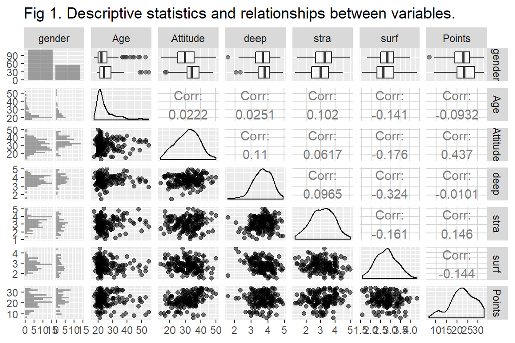

```
##  gender       Age           Attitude          deep            stra
##  F:110   Min.   :17.00   Min.   :14.00   Min.   :1.583   Min.   :1.250
##  M: 56   1st Qu.:21.00   1st Qu.:26.00   1st Qu.:3.333   1st Qu.:2.625
##          Median :22.00   Median :32.00   Median :3.667   Median :3.188
##          Mean   :25.51   Mean   :31.43   Mean   :3.680   Mean   :3.121
##          3rd Qu.:27.00   3rd Qu.:37.00   3rd Qu.:4.083   3rd Qu.:3.625
##          Max.   :55.00   Max.   :50.00   Max.   :4.917   Max.   :5.000
##       surf           Points
##  Min.   :1.583   Min.   : 7.00
##  1st Qu.:2.417   1st Qu.:19.00
##  Median :2.833   Median :23.00
##  Mean   :2.787   Mean   :22.72
##  3rd Qu.:3.167   3rd Qu.:27.75
##  Max.   :4.333   Max.   :33.00
```

### Linear regression analysis with exam points as the dependent variable (tasks 3 and 4)

I did a multiple linear regression analysis with exam points as the dependent variable and gender, age, and attitude to statistics as the independent variables. Of the independent variables, attitude to statistics is associated with better exam points (estimate 0.36, p < 0.001).

The association of gender and age with exam points is statistically insignificant, suggesting no relationship between these predictors and the outcome when controlling for all these three independent variables.

The value of multiple R-squared is 0.20, which means that the model explains 20% of the variation in the dependent variable (i.e. exam points).

```
##
## Call:
## lm(formula = Points ~ gender + Age + Attitude, data = regr_analysis)
##
## Residuals:
##      Min       1Q   Median       3Q      Max
## -17.4590  -3.3221   0.2186   4.0247  10.4632
##
## Coefficients:
##             Estimate Std. Error t value Pr(>|t|)
## (Intercept) 13.42910    2.29043   5.863 2.48e-08 ***
## genderM     -0.33054    0.91934  -0.360    0.720
## Age         -0.07586    0.05367  -1.414    0.159
## Attitude     0.36066    0.05932   6.080 8.34e-09 ***
## ---
## Signif. codes:  0 '***' 0.001 '**' 0.01 '*' 0.05 '.' 0.1 ' ' 1
##
## Residual standard error: 5.315 on 162 degrees of freedom
## Multiple R-squared:  0.2018, Adjusted R-squared:  0.187
## F-statistic: 13.65 on 3 and 162 DF,  p-value: 5.536e-08
```

The value of multiple R-squared in the latter model is 0.19, which means that the model explains 19% of the variation in the dependent variable (i.e. exam points). This value is lower by 0.01 compared to the model above, indicating that the model above explained slightly larger part of the variation in exam points.

```
##
## Call:
## lm(formula = Points ~ Attitude, data = regr_analysis)
##
## Residuals:
##      Min       1Q   Median       3Q      Max
## -16.9763  -3.2119   0.4339   4.1534  10.6645
##
## Coefficients:
##             Estimate Std. Error t value Pr(>|t|)
## (Intercept) 11.63715    1.83035   6.358 1.95e-09 ***
## Attitude     0.35255    0.05674   6.214 4.12e-09 ***
## ---
## Signif. codes:  0 '***' 0.001 '**' 0.01 '*' 0.05 '.' 0.1 ' ' 1
##
## Residual standard error: 5.32 on 164 degrees of freedom
## Multiple R-squared:  0.1906, Adjusted R-squared:  0.1856
## F-statistic: 38.61 on 1 and 164 DF,  p-value: 4.119e-09
```

### Diagnostic tests (task 5)

Linear regression model assumes first that the association between the variables of interest is linear. Second, errors between predicted and observed values of the dependent variable should be normally distributed.

We can explore the assumption that the errors are normally distributed by looking at QQ-plot (Normal Q-Q in the figure below). The plot shows that errors follow the line in the plot reasonably well, indicating that the model is reasonably well in line with the normality assumption.

One additional assumption in linear regression is that variance of errors is constant across values of dependent variable. Thus, an implication of this is that errors are not dependent on independent variables.

To test this assumption, we can explore a plot that shows the relationship between residuals and predicted values (Residuals vs fitted in the figure below). There should be no visible pattern in the plot if the assumption holds true. This seems to be the case in our plot in which the points are quite randomly scattered.

Finally, I tested how much impact single observation has on the model by exporing residual vs. leverage plot. Observing this plot shows that there are no observations that would stand out from others, suggesting that any single observation has not got a significant impact on the model.

Taken together, these three diagnostic plots show no sign of problems with modelling assumptions.

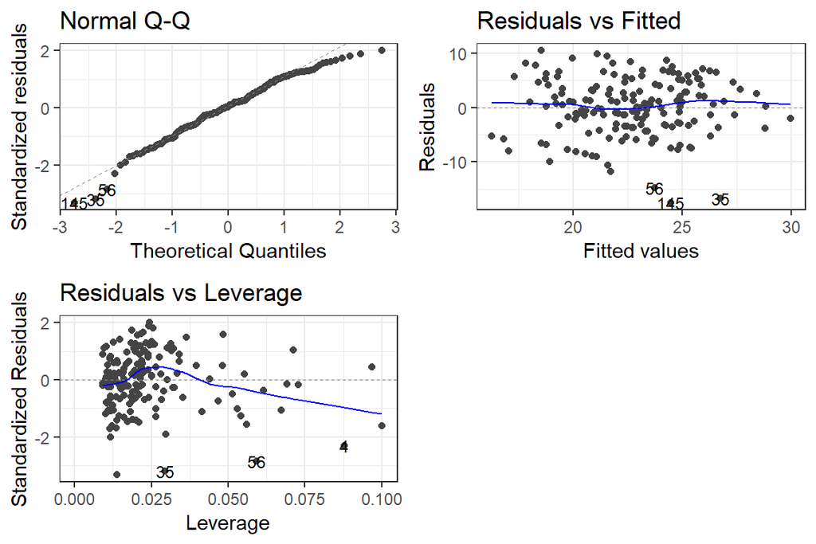

# Logistic regression

I am using data on student achievement from two Portugese schools. The data has records of student achievement and social and demographic background. In addition, the data contains variables on students’ alcohol consumption. Thus, it is possible to analyse the relationship between alcohol consumption and some other student characteristcs, which is the purpose of this exercise. Below are the names of the variables in the data.

```r
names(alc)
```

```
##  [1] "school"     "sex"        "age"        "address"    "famsize"
##  [6] "Pstatus"    "Medu"       "Fedu"       "Mjob"       "Fjob"
## [11] "reason"     "nursery"    "internet"   "guardian"   "traveltime"
## [16] "studytime"  "failures"   "schoolsup"  "famsup"     "paid"
## [21] "activities" "higher"     "romantic"   "famrel"     "freetime"
## [26] "goout"      "Dalc"       "Walc"       "health"     "absences"
## [31] "G1"         "G2"         "G3"         "alc_use"    "high_use"
```

In this excercise, I have chosen to analyze the following four variables in relation to student’s alcohol consumption: student’s sex, student’s maternal education, extra curricular activities, and school achievement.

My hypothesis is that each of these variables are associated with alcohol consumption.

1. Boys use more alcohol than girls.
2. Student’s with low maternal education use more alcohol than those with high maternal education.
3. Extracurricular activities are related to lower alcohol consumption.
4. Higher school achievement is associated with lower alcohol consumption.

### Descriptive data

There are slightly more girl than boys in the data.

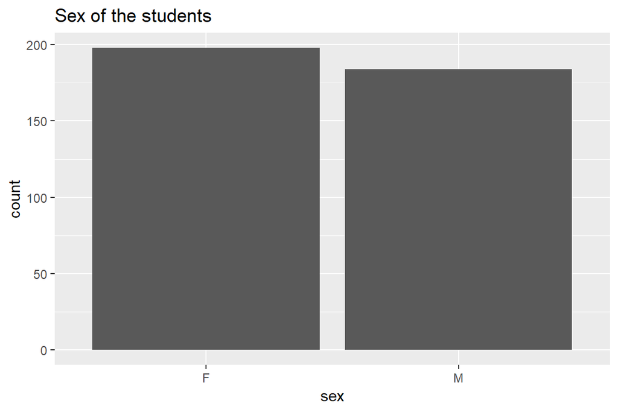

```r
ggplot(alc2, aes(x = sex)) +
  geom_bar() +
  ggtitle("Sex of the students")
```

There are more mother’s with high education (4) than low education (0).

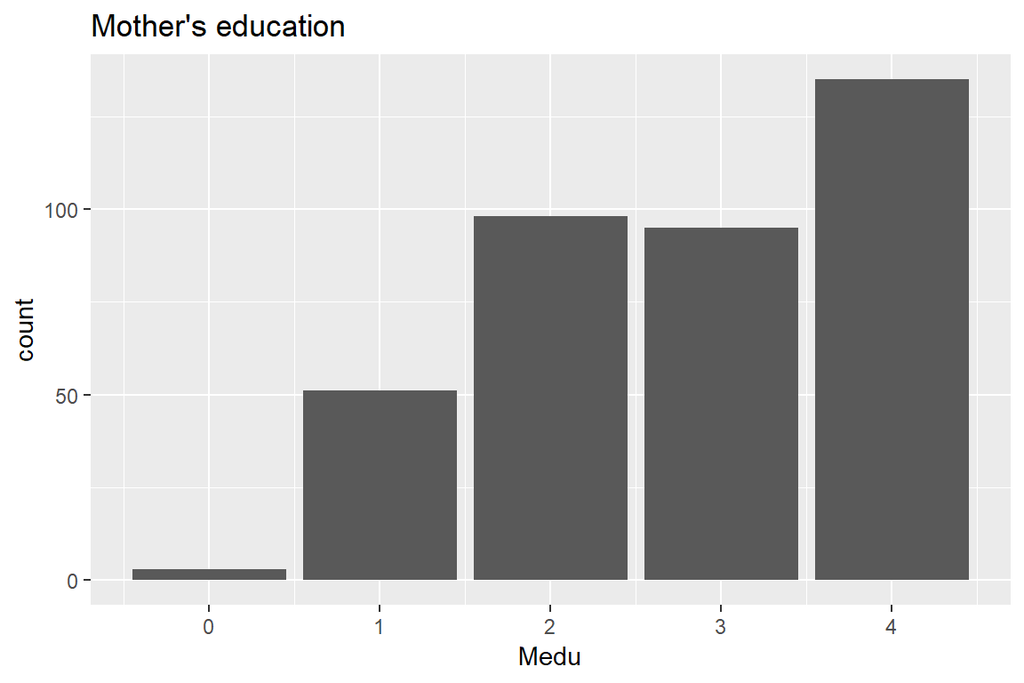

```r
ggplot(alc2, aes(x = Medu)) +
  geom_bar() +
  ggtitle("Mother's education")
```

Somewhat more students participate in extracurricular activities than not.

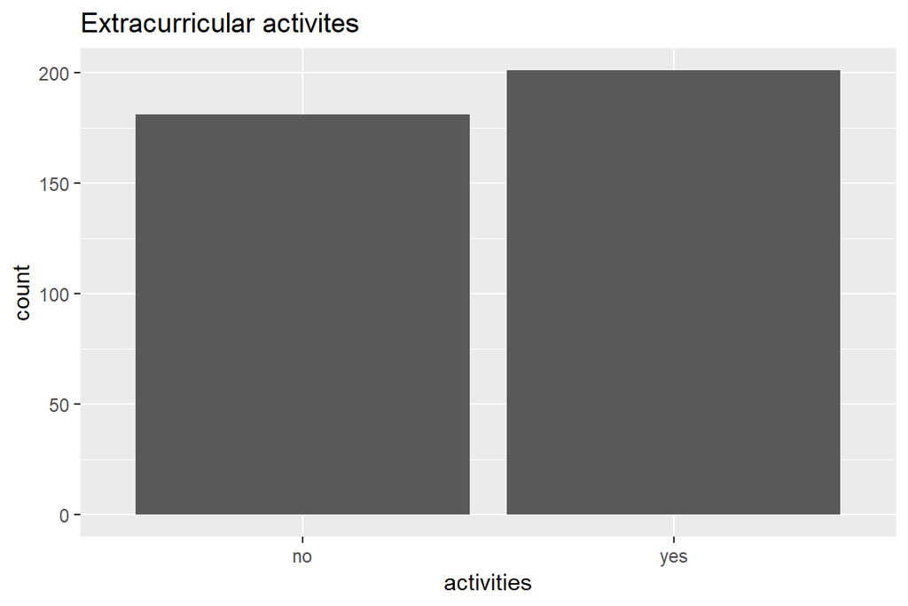

```r
ggplot(alc2, aes(x = activities)) +
  geom_bar() +
  ggtitle("Extracurricular activites")
```

Student’s median alcohol use is 1,5, with 1 indicating very low alcohol use and 5 indicating very high use.

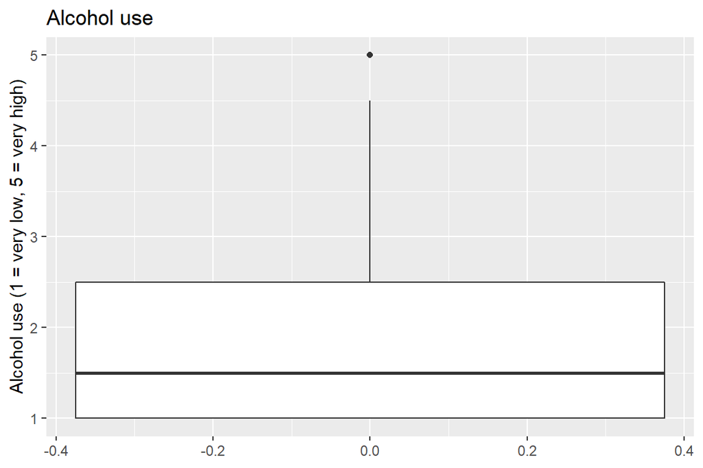

```r
ggplot(alc2, aes(y = alc_use)) +
  geom_boxplot() +
  ylab("Alcohol use (1 = very low, 5 = very high)") +
  ggtitle("Alcohol use")
```

Median school achievement is 11.

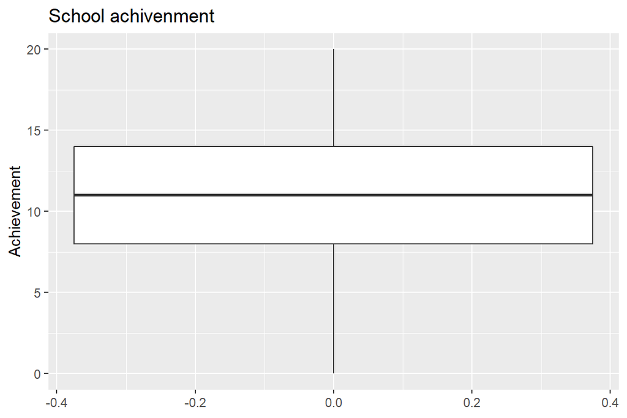

```r
ggplot(alc2, aes(y = G3)) +
  geom_boxplot() +
  ylab("Achievement") +
  ggtitle("School achivenment")
```

### Relationships between variables

Boys use more alcohol than girls, as hypothesized.

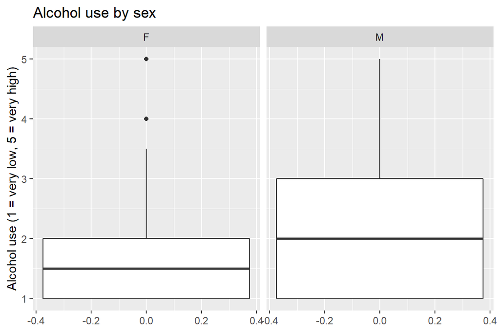

```r
ggplot(alc2, aes(y = alc_use)) +
  geom_boxplot() +
  ylab("Alcohol use (1 = very low, 5 = very high)") +
  ggtitle("Alcohol use by sex") +
  facet_wrap(~ sex)
```

Unlike hypothesized, there are limited differences in alcohol use by maternal education.

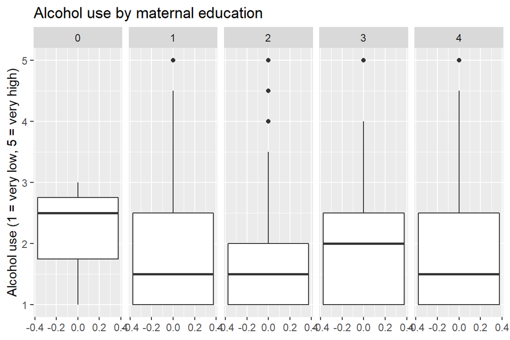

```r
ggplot(alc2, aes(y = alc_use)) +
  geom_boxplot() +
  ylab("Alcohol use (1 = very low, 5 = very high)") +
  ggtitle("Alcohol use by maternal education") +
  facet_wrap(~ Medu, nrow = 1)
```

Unlike hyptohesized, those participationg in extracurricular activities consume alcohol similarly to those who do not have extracurricular activities.

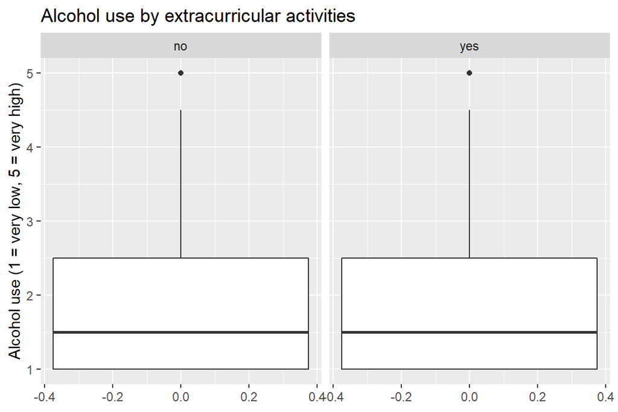

```r
ggplot(alc2, aes(y = alc_use)) +
  geom_boxplot() +
  ylab("Alcohol use (1 = very low, 5 = very high)") +
  ggtitle("Alcohol use by extracurricular activities") +
  facet_wrap(~ activities, nrow = 1)
```

As suggested by the horizonal directions of the blue line, unlike hypothesized, there seems to be no relationship between alcohol consumption and school achievement, or at least the relationship is not linear and clearly visible.

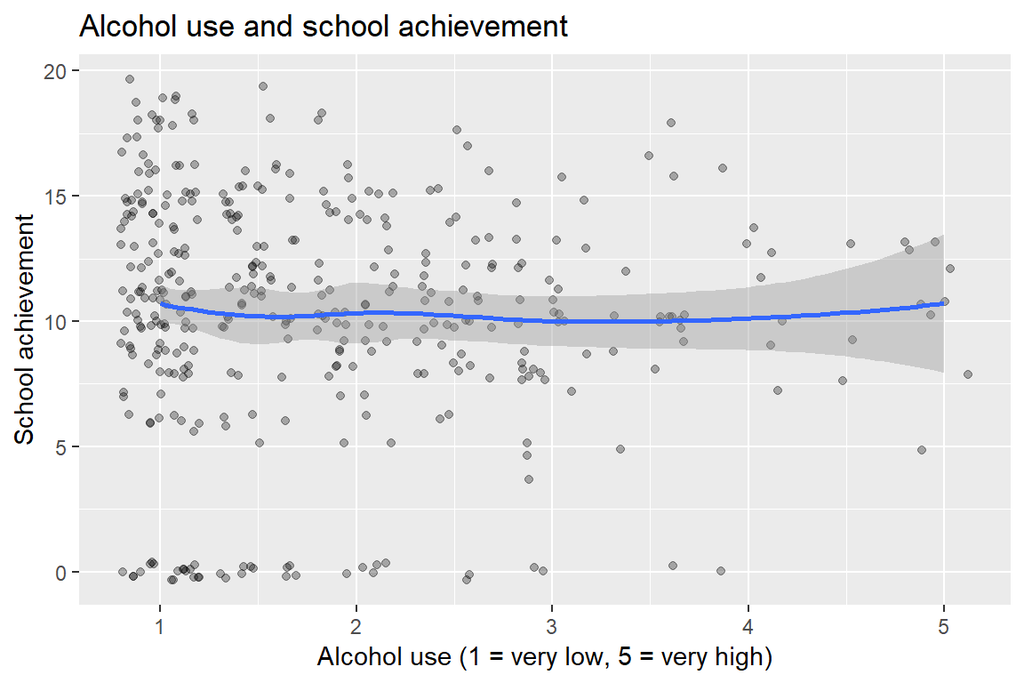

```r
ggplot(alc2, aes(x = alc_use, y = G3)) +
  geom_jitter(alpha = 0.3) +
  geom_smooth() +
  xlab("Alcohol use (1 = very low, 5 = very high)") +
  ylab("School achievement") +
  ggtitle("Alcohol use and school achievement")
```

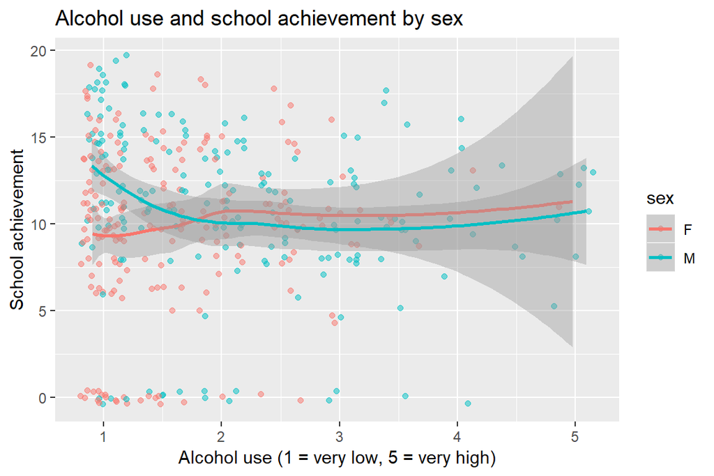

```r
ggplot(alc2, aes(x = alc_use, y = G3, color = sex)) +
  geom_jitter(alpha = 0.5) +
  geom_smooth(aes(x = jitter(alc_use))) +
  xlab("Alcohol use (1 = very low, 5 = very high)") +
  ylab("School achievement") +
  ggtitle("Alcohol use and school achievement by sex")
```